# Progetto Statistica Inferenziale

Gabriele Carleo

06/03/2022

Il corso che mi ha permesso di apprendere le competenze per svolgere questo progetto è **Statistica Inferenziale**, l’insegnate è [Giuseppe Dejan Lucido](https://www.giuseppedejanlucido.it/) che ringrazio. Il corso fa parte del **Data science professional path** prodotto da [Profession AI](https://www.profession.ai/home).

Per questo studio medico analizzerò i dati raccolti in 3 ospedali, riguardanti 2500 neonati.

Le variabili che sono state rilevate sono:

- Età della madre
- Numero di gravidanze sostenute
- Madre fumatrice (0=NO, 1=SI)
- Numero di settimane di gestazione
- Peso in grammi del neonato
- Lunghezza in millimetri del neonato
- Diamentro in millimentri del neonato
- Tipo di parto: Naturale o Cesareo
- Ospedale: 1, 2, 3
- Sesso del neonato: F, M

L’obiettivo dello studio è scoprire se è possibile prevedere il peso del neonato alla nascita date tutte le altre variabili.

La traccia del progetto è strutturata in più punti, che riporterò per una più chiara e semplice comprensione.

# 1 Importare il dataset

Utilizzando la funzione `read.csv()` importo il dataset *neonati.csv*

```r
df <- read.csv("neonati.csv",
               sep = ",",
               stringsAsFactors = T)
```

# 2 Descrizione del dataset, la sua composizione e il tipo di variabili

Di seguito esploro il dataset con la funzione `head()` che di default mostrerà le prime 6 righe:

```r
head(df)
```

```
##   Anni.madre N.gravidanze Fumatrici Gestazione Peso Lunghezza Cranio Tipo.parto
## 1         26            0         0         42 3380       490    325        Nat
## 2         21            2         0         39 3150       490    345        Nat
## 3         34            3         0         38 3640       500    375        Nat
## 4         28            1         0         41 3690       515    365        Nat
## 5         20            0         0         38 3700       480    335        Nat
## 6         32            0         0         40 3200       495    340        Nat
##   Ospedale Sesso
## 1     osp3     M
## 2     osp1     F
## 3     osp2     M
## 4     osp2     M
## 5     osp3     F
## 6     osp2     F
```

Il dataset in esame è composto da **10 variabili** e **2500 osservazioni.**

Le *tipologie di variabili* sono:

- Età della madre: **Quantitativa** o numerica **discreta**
- Numero di gravidanze sostenute: **Quantitativa** o numerica **discreta**
- Madre fumatrice (0=No, 1=Si): **Qualitativa codificata** in numeri (fattori)
- Numero di settimane di gestazione: **Quantitativa** o numerica **discreta**
- Peso in grammi del neonato: **Quantitativa** o numerica **continua**
- Lunghezza in mm del neonato: **Quantitativa** o numerica **continua**
- Diametro in mm del cranio del neonato: **Quantitativa** o numerica **continua**
- Tipo di parto (naturale o cesareo): **Qualitativa** o categoriale **su scala nominale**
- Ospedale (1,2 o 3): **Qualitativa** o categoriale **su scala nominale**
- Sesso del neonato (M o F): **Qualitativa** o categoriale **dicotomica**

# 3 Analisi descrittiva delle variabili, utilizzando indici e strumenti grafici

Per pirma cosa mi assicuro che nel *dataset* non siano presenti valori mancanti, la seguente funzione `colSums(is.na())` somma i valori mancanti (na) per ogni variabile:

```r
colSums(is.na(df))
```

```
##   Anni.madre N.gravidanze    Fumatrici   Gestazione         Peso    Lunghezza
##            0            0            0            0            0            0
##       Cranio   Tipo.parto     Ospedale        Sesso
##            0            0            0            0
```

**Nessun valore mancante**

Di seguito una rappresentazione grafica del *dataset*:

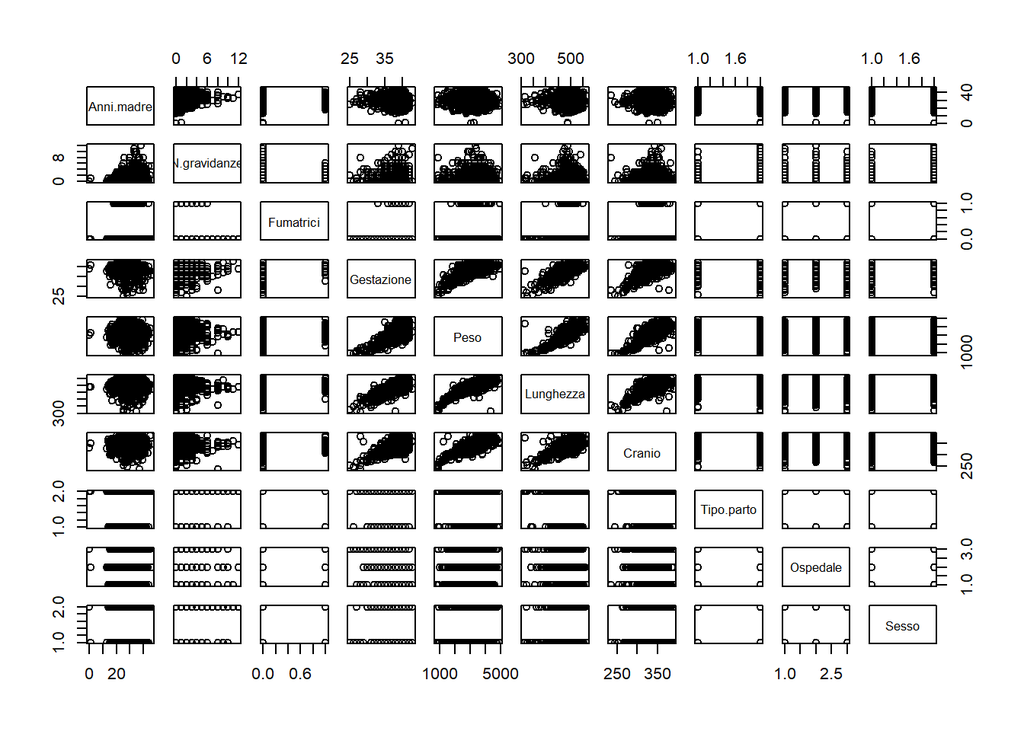

```r
plot(df)
```

Tenendo a mente l’obiettivo dello studio, noto che le variabili *Gestazione*, *Lunghezza* e *Cranio* mostrano una **correlazione lineare positiva** con la variabile **Peso**. Questo verrà saggiato apporfonditamente nei punti successivi.

Ora utilizzo la funzione `summary()` sul *dataset* per produrre un riepilogo per tutte le variabili

```r
summary(df)
```

```
##    Anni.madre     N.gravidanze       Fumatrici        Gestazione
##  Min.   : 0.00   Min.   : 0.0000   Min.   :0.0000   Min.   :25.00
##  1st Qu.:25.00   1st Qu.: 0.0000   1st Qu.:0.0000   1st Qu.:38.00
##  Median :28.00   Median : 1.0000   Median :0.0000   Median :39.00
##  Mean   :28.16   Mean   : 0.9812   Mean   :0.0416   Mean   :38.98
##  3rd Qu.:32.00   3rd Qu.: 1.0000   3rd Qu.:0.0000   3rd Qu.:40.00
##  Max.   :46.00   Max.   :12.0000   Max.   :1.0000   Max.   :43.00
##       Peso        Lunghezza         Cranio    Tipo.parto Ospedale   Sesso
##  Min.   : 830   Min.   :310.0   Min.   :235   Ces: 728   osp1:816   F:1256
##  1st Qu.:2990   1st Qu.:480.0   1st Qu.:330   Nat:1772   osp2:849   M:1244
##  Median :3300   Median :500.0   Median :340              osp3:835
##  Mean   :3284   Mean   :494.7   Mean   :340
##  3rd Qu.:3620   3rd Qu.:510.0   3rd Qu.:350
##  Max.   :4930   Max.   :565.0   Max.   :390
```

Valore anomalo per la variabile *Anni.madre*: `Min. : 0.00`

## 3.1 Rappresentazione grafica e sintesi delle variabili

Variabile: **Tipo Parto**

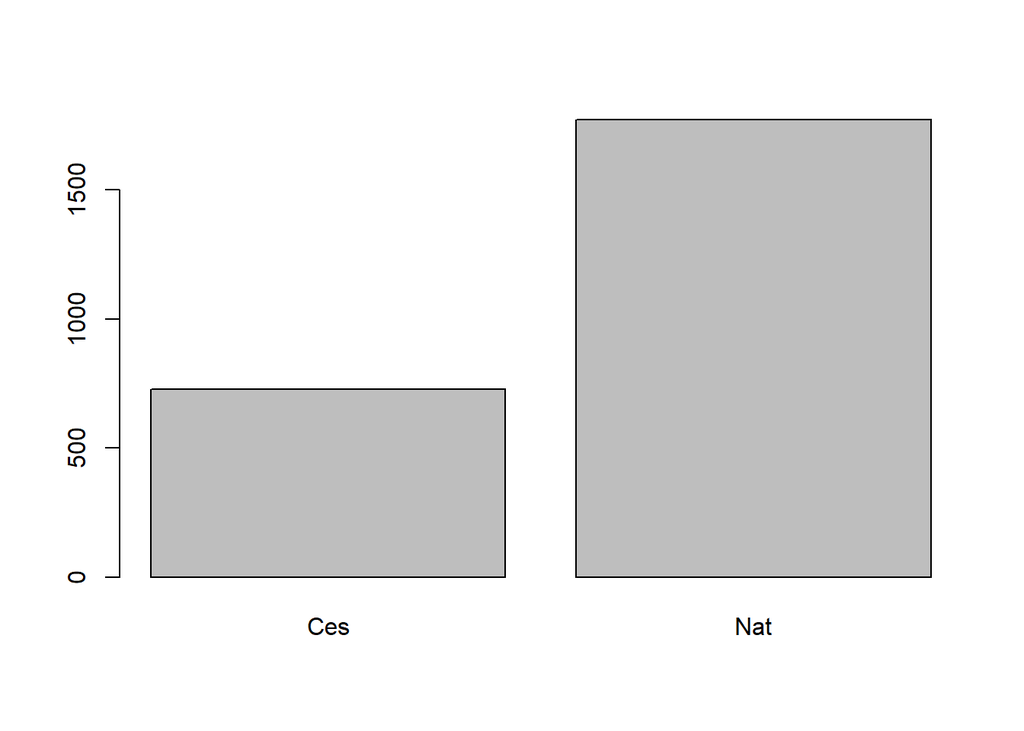

```r
plot(Tipo.parto)
```

```r
summary(Tipo.parto)
```

```
##  Ces  Nat
##  728 1772
```

Variabile: **Ospedale**

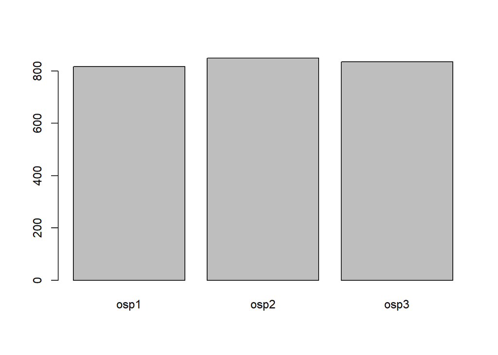

```r
plot(Ospedale)
```

```r
summary(Ospedale)
```

```
## osp1 osp2 osp3
##  816  849  835
```

Variabile: **Sesso**

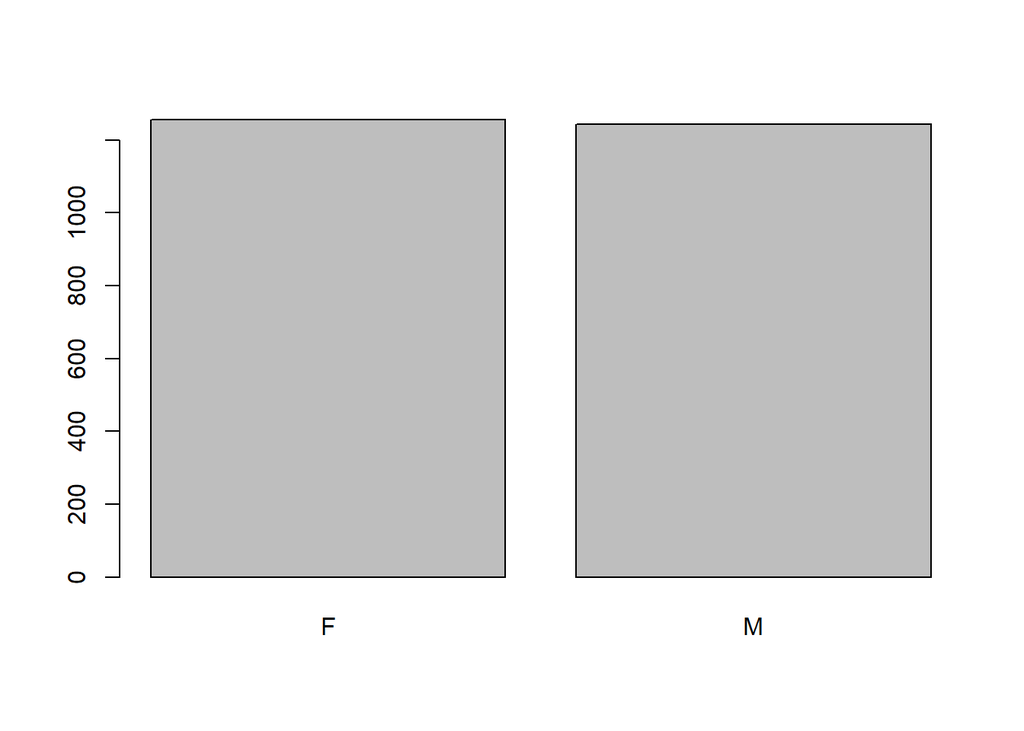

```r
plot(Sesso)
```

```r
summary(Sesso)
```

```
##    F    M
## 1256 1244
```

Variabile: **Lunghezza**

Con la seguente funzione `par(mfrow = c(1, 2))` divido la finestra grafica in una riga e due colonne così da poter visualizzare due grafici affiancati.

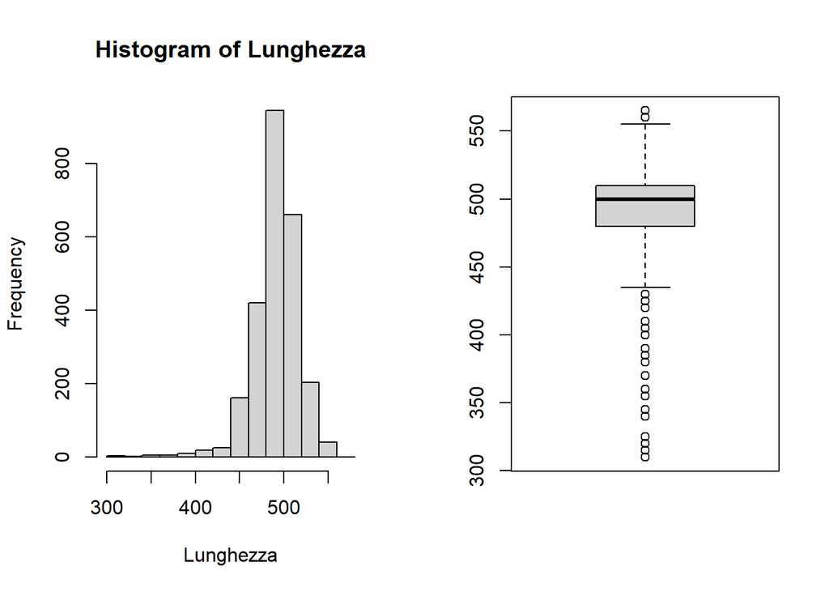

```r
par(mfrow = c(1, 2))
hist(Lunghezza)
boxplot(Lunghezza)
```

```r
summary(Lunghezza)
```

```
##    Min. 1st Qu.  Median    Mean 3rd Qu.    Max.
##   310.0   480.0   500.0   494.7   510.0   565.0
```

Variabile: **Cranio**

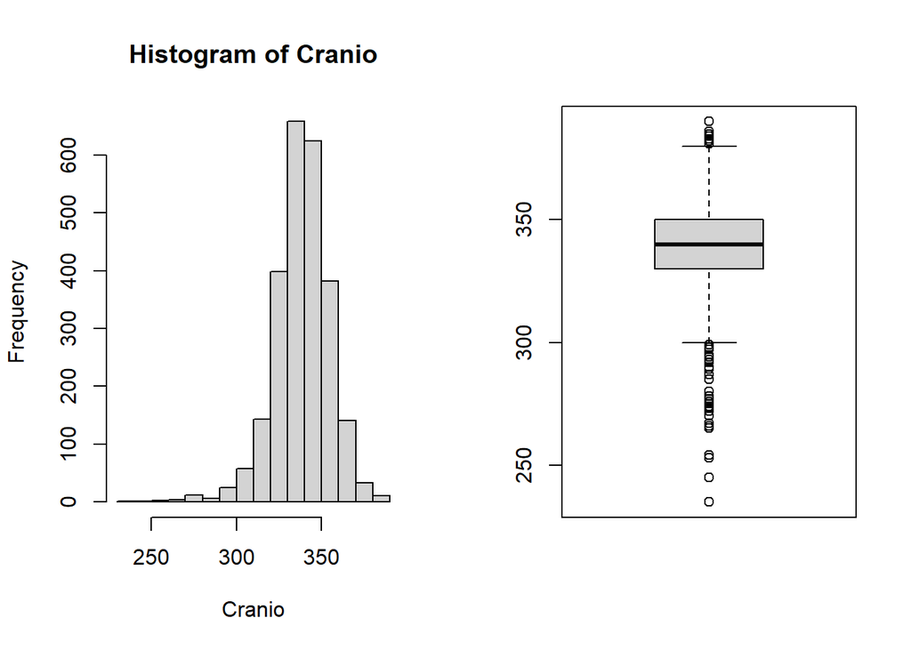

```r
par(mfrow = c(1, 2))
hist(Cranio)
boxplot(Cranio)
```

```r
summary(Cranio)
```

```
##    Min. 1st Qu.  Median    Mean 3rd Qu.    Max.
##     235     330     340     340     350     390
```

Variabile: **Anni Madre**

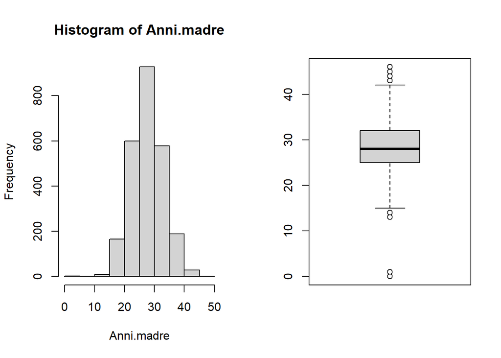

```r
par(mfrow = c(1, 2))
hist(Anni.madre)
boxplot(Anni.madre)
```

```r
summary(Anni.madre)
```

```
##    Min. 1st Qu.  Median    Mean 3rd Qu.    Max.
##    0.00   25.00   28.00   28.16   32.00   46.00
```

Presenza di valori anomali per la variabile *Anni Madre*, 0 ed 1 anno inseriti.

Variabile: **Numero di Gravidanze**

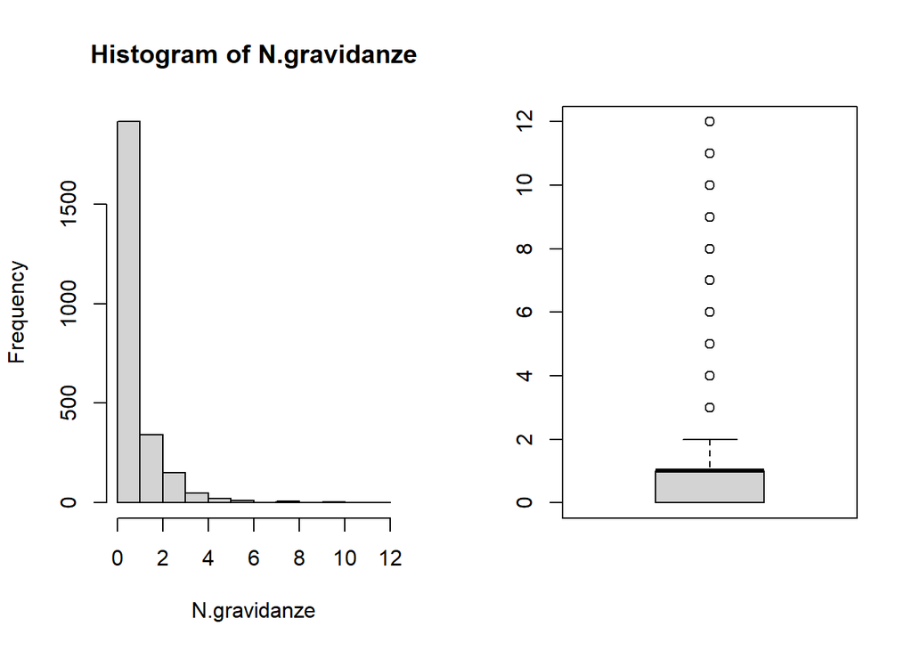

```r
par(mfrow = c(1, 2))
hist(N.gravidanze)
boxplot(N.gravidanze)
```

```r
summary(N.gravidanze)
```

```
##    Min. 1st Qu.  Median    Mean 3rd Qu.    Max.
##  0.0000  0.0000  1.0000  0.9812  1.0000 12.0000
```

Variabile: **Settiamne di Gestazione**

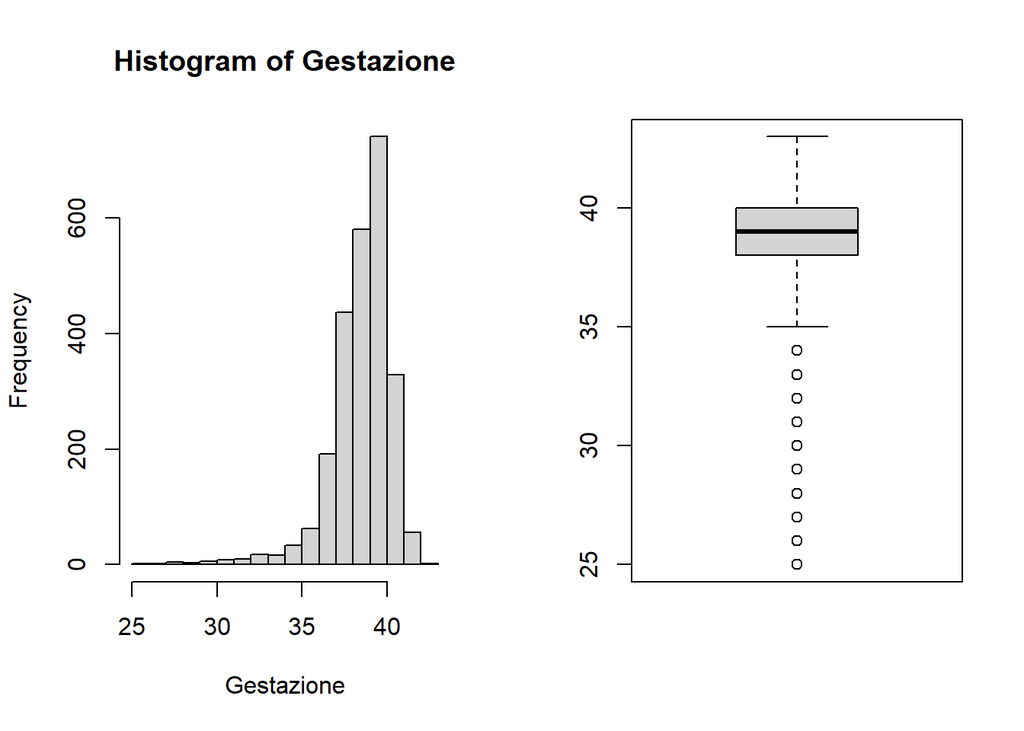

```r
par(mfrow = c(1, 2))
hist(Gestazione)
boxplot(Gestazione)
```

```r
summary(Gestazione)
```

```
##    Min. 1st Qu.  Median    Mean 3rd Qu.    Max.
##   25.00   38.00   39.00   38.98   40.00   43.00
```

Variabile: **Peso**

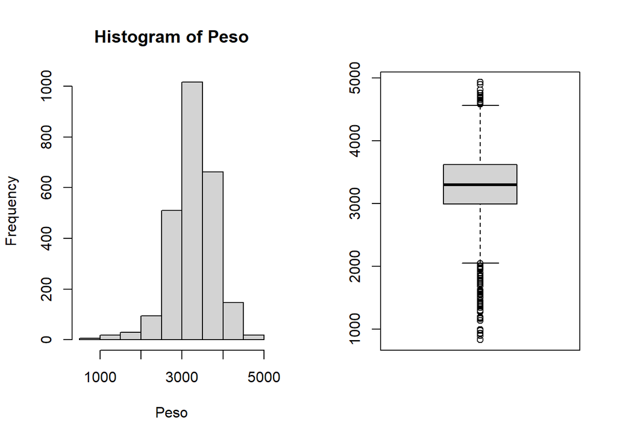

```r
par(mfrow = c(1, 2))
hist(Peso)
boxplot(Peso)
```

```r
summary(Peso)
```

```
##    Min. 1st Qu.  Median    Mean 3rd Qu.    Max.
##     830    2990    3300    3284    3620    4930
```

Variabile: **Fumatrici**

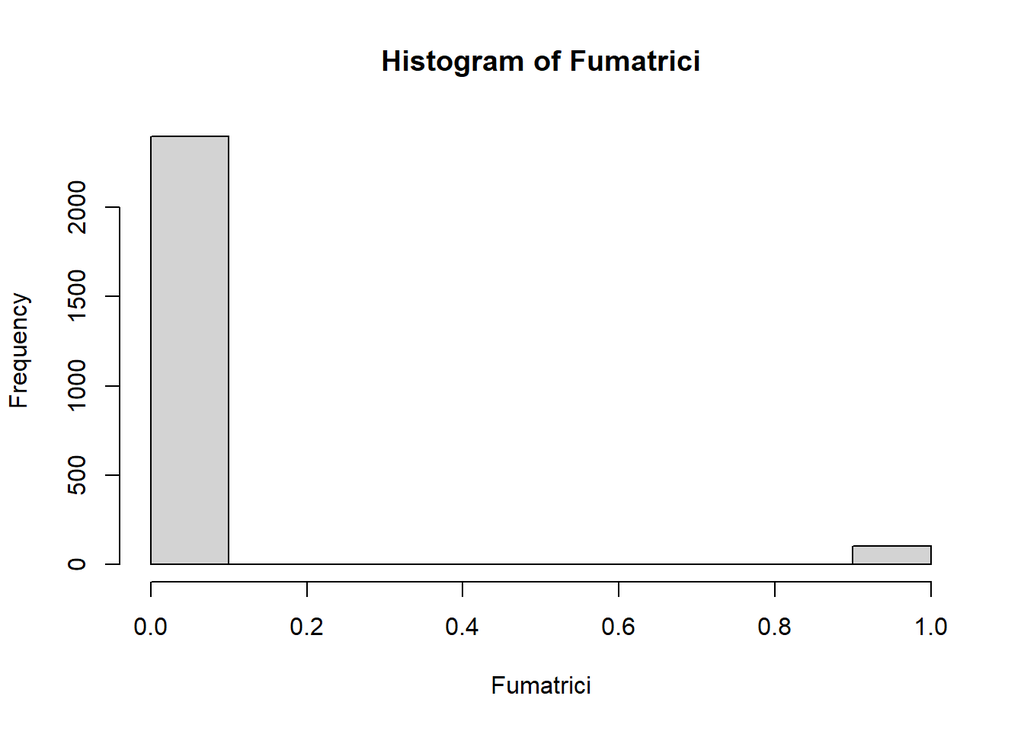

```r
hist(Fumatrici)
```

```r
summary(Fumatrici)
```

```
##    Min. 1st Qu.  Median    Mean 3rd Qu.    Max.
##  0.0000  0.0000  0.0000  0.0416  0.0000  1.0000
```

## 3.2 Indici di forma

Di seguito andrò a calcolare **l’indice di asimmetria di Fisher** utilizzando la funzione `skewness()` ed il **Coefficiente di Curtosi** con la funzione `kurtosis()-3` (*-3 per centrare l’indice sullo 0*). Entrambe le funzioni fanno parte del pacchetto *moments* che andrò a caricare con `library(moments)`.

**Indice di asimmetria di Fisher**

Di seguito un riepilogo su come interpretare i risultati della funzione `skewness()`, dove *y1* è *l’indice di asimmetria di Fisher*:

y1 = 0, la distribuzione è **simmetrica**

y1 > 0, la distribuzione è **asimmetrica positiva**

y1 < 0, la distribuzione è **asimmetrica negativa**

**Coefficiente di Curtosi**

Di seguito un riepilogo per interpretare i risultati della funzione `kurtosis()-3`, dove *y2* è *il coefficiente di Curtosi*:

y2 = 0, la distribuzione **mesocurtica**

y2 > 0, la distribuzione **leptocurtica**

y2 < 0, la distribuzione **platicurtica**

```r
library(moments)
library(ggplot2)
```

Variabile: **Anni Madre**

```r
skewness(Anni.madre)
```

```
## [1] 0.0428115
```

```r
kurtosis(Anni.madre)-3
```

```
## [1] 0.3804165
```

Per la variabile **Anni Madre** la distribuzione è *simmetrica leptocurtica*

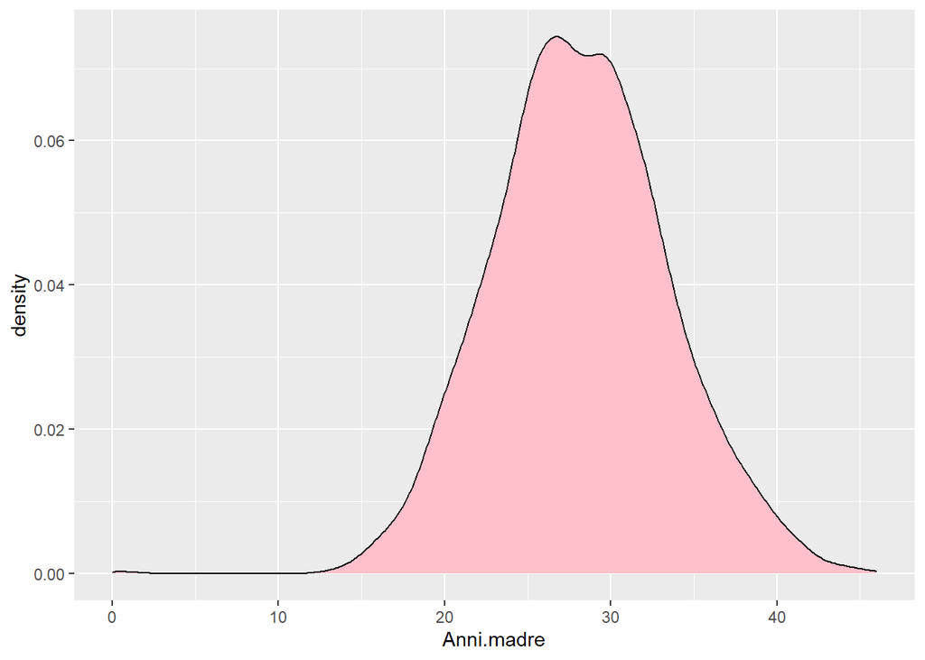

```r
ggplot()+
  geom_density(aes(x=Anni.madre),col="black",fill="pink")
```

Variabile: **Numero di Gravidanze**

```r
skewness(N.gravidanze)
```

```
## [1] 2.514254
```

```r
kurtosis(N.gravidanze)-3
```

```
## [1] 10.98941
```

Per la variabile **Numero di Gravidanze** la distribuzione è *asimmetrica positiva leptocurtica*

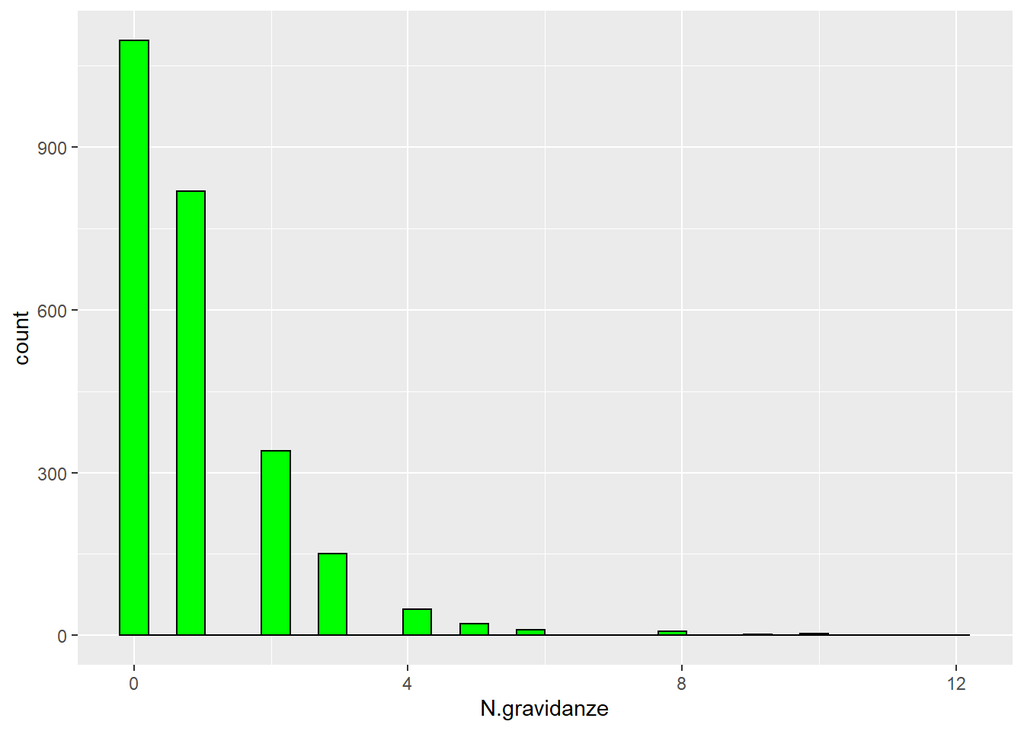

```r
ggplot()+
  geom_histogram(aes(x=N.gravidanze),col="black",fill="green")
```

Variabile: **Settiamne di Gestazione**

```r
skewness(Gestazione)
```

```
## [1] -2.065313
```

```r
kurtosis(Gestazione)-3
```

```
## [1] 8.25815
```

Per la variabile **Settiamne di Gestazione** la distribuzione è *asimmetrica negativa leptocurtica*

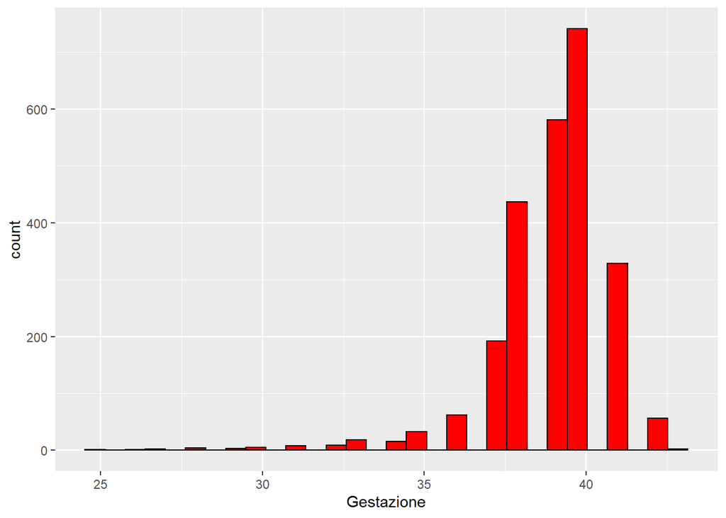

```r
ggplot()+
  geom_histogram(aes(x=Gestazione),col="black",fill="red")
```

Variabile: **Peso**

```r
skewness(Peso)
```

```
## [1] -0.6470308
```

```r
kurtosis(Peso)-3
```

```
## [1] 2.031532
```

Per la variabile **Peso** la distribuzione è *asimmetrica negativa leptocurtica*

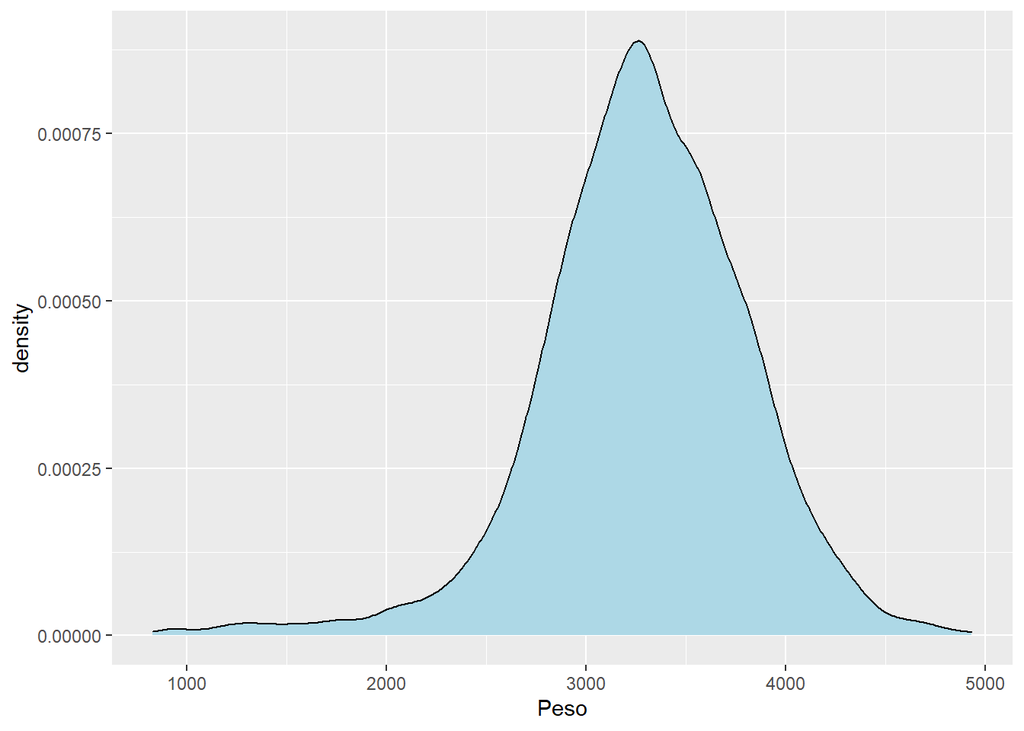

```r
ggplot()+
  geom_density(aes(x=Peso),col="black",fill="lightblue")
```

Variabile: **Lunghezza**

```r
skewness(Lunghezza)
```

```
## [1] -1.514699
```

```r
kurtosis(Lunghezza)-3
```

```
## [1] 6.487174
```

Per la variabile **Lunghezza** la distribuzione è *asimmetrica negativa leptocurtica*

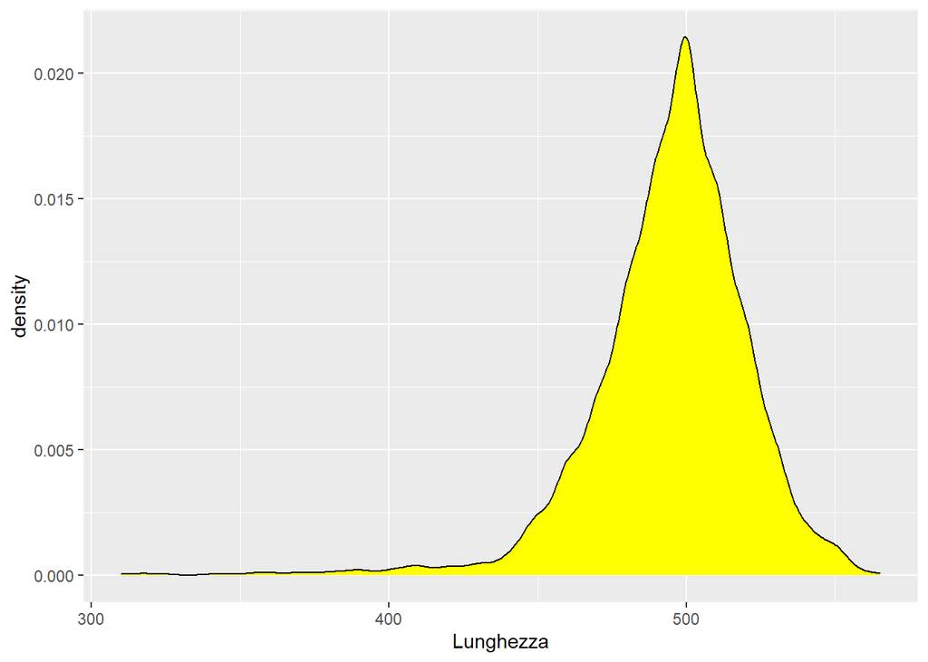

```r
ggplot()+
  geom_density(aes(x=Lunghezza),col="black",fill="yellow")
```

Variabile: **Cranio**

```r
skewness(Cranio)
```

```
## [1] -0.7850527
```

```r
kurtosis(Cranio)-3
```

```
## [1] 2.946206
```

Per la variabile **Cranio** la distribuzione è *asimmetrica negativa leptocurtica*

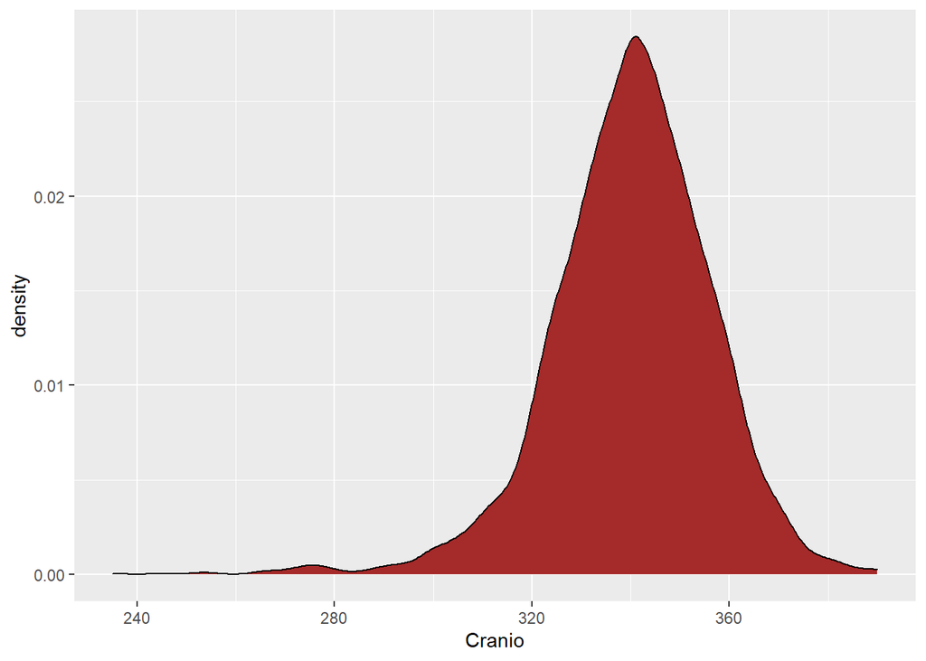

```r
ggplot()+
  geom_density(aes(x=Cranio),col="black",fill="brown")
```

## 3.3 Indici di posizione

### 3.3.1 Distribuzione di Frequenza

- Di seguito calcolo la **distribuzione di frequenza** per evidenziare informazioni sulle *Madri* fumatrici e non fumatrici:

```r
N<-dim(df)[1]
freq.ass.fum<-table(Fumatrici)
freq.rel.fum<-table(Fumatrici)/N
(distr_freq_fum<-cbind(freq.ass.fum,freq.rel.fum))
```

```
##   freq.ass.fum freq.rel.fum
## 0         2396       0.9584
## 1          104       0.0416
```

Dalla distribuzione di frequenza calcolata sopra evidenziamo che *2396 Madri non sono fumatrici* e rappresentano circa il 96% delle osservazioni, mentre le *madri fumatrici sono 104*, circa il 4%.

- Calcolo della **distribuzione di frequenza** sul numero di gravidanze sostenute:

```r
freq.ass.ngrav<-table(N.gravidanze)
freq.rel.ngrav<-table(N.gravidanze)/N
(distr_freq_ngrav<-cbind(freq.ass.ngrav,freq.rel.ngrav))
```

```
##    freq.ass.ngrav freq.rel.ngrav
## 0            1096         0.4384
## 1             818         0.3272
## 2             340         0.1360
## 3             150         0.0600
## 4              48         0.0192
## 5              21         0.0084
## 6              11         0.0044
## 7               1         0.0004
## 8               8         0.0032
## 9               2         0.0008
## 10              3         0.0012
## 11              1         0.0004
## 12              1         0.0004
```

Per interpretare la distribuzione di frequenza sopra calcolata possiamo prendere come esempio la riga `## 0`:

- il valore sotto *freq.ass.ngrav*, nell’es. 1096, indica il numero di osservazioni (la somma di madri) che hanno avuto 0 gravidanze precedenti.
- Mentre il valore sotto *freq.rel.ngrav* lo indica in forma percentuale, quindi il 43,84% delle madri presenti nel dataset non hanno partorito, precedentemente, altri neonati.

## 3.4 Indici di Variabilità

In statistica, un *indice di dispersione* (o indicatore di dispersione o indice di variabilità o *indice di variazione*) è un indice che descrive sinteticamente la variabilità di una distribuzione statistica quantitativa. In modo particolare misura quanto i valori presenti nella distribuzione distano da un valore centrale scelto come riferimento. Il valore centrale è solitamente un indice di posizione. I valori centrali più usati nelle applicazioni sono *media* e *mediana.* [Fonte Wikipedia](https://it.wikipedia.org/wiki/Indice_di_dispersione#:~:text=In%20statistica%2C%20un%20indice%20di,di%20una%20distribuzione%20statistica%20quantitativa.)

### 3.4.1 Scarto interquartile

In statistica lo **scarto interquartile** (in inglese interquartile range o *IQR*) è la differenza tra il terzo e il primo quartile, ovvero l’ampiezza della fascia di valori che contiene la metà “centrale” dei valori osservati. Lo scarto interquartile è un indice di dispersione, *cioè una misura di quanto i valori si allontanino da un valore centrale*. [Fonte Wikipedia](https://it.wikipedia.org/wiki/Scarto_interquartile)

Di seguito calcolerò lo scarto interquartile utilizzando la funzione `IQR()`:

```r
IQR(Anni.madre)
```

```
## [1] 7
```

```r
IQR(N.gravidanze)
```

```
## [1] 1
```

```r
IQR(Gestazione)
```

```
## [1] 2
```

```r
IQR(Peso)
```

```
## [1] 630
```

```r
IQR(Lunghezza)
```

```
## [1] 30
```

```r
IQR(Cranio)
```

```
## [1] 20
```

### 3.4.2 Varianza

In statistica la varianza di una variabile statistica è una funzione che fornisce una misura della variabilità dei valori assunti dalla variabile stessa; nello specifico, la misura di quanto essi si discostino quadraticamente rispettivamente dalla media aritmetica o dal valore atteso. [Fonte Wikipedia](https://it.wikipedia.org/wiki/Varianza#Definizione)

La funzione che utilizzerò per calcolare la **Varianza** è `var()`:

```r
var(Anni.madre)
```

```
## [1] 27.81063
```

```r
var(N.gravidanze)
```

```
## [1] 1.639903
```

```r
var(Gestazione)
```

```
## [1] 3.491813
```

```r
var(Peso)
```

```
## [1] 275665.7
```

```r
var(Lunghezza)
```

```
## [1] 692.671
```

```r
var(Cranio)
```

```
## [1] 269.7915
```

Essendo la *Varianza* un *valore quadrato* è difficile contestualizzarlo, pertanto calcolerò la **deviazione standard** *che altro non è che la radice quadrata della varianza*.

### 3.4.3 Deviazione Standard

Il calcolo della deviazione standard può essere effettuato utilizzando la funzione `sd()`:

```r
sd(Anni.madre)
```

```
## [1] 5.273578
```

```r
sd(N.gravidanze)
```

```
## [1] 1.280587
```

```r
sd(Gestazione)
```

```
## [1] 1.868639
```

```r
sd(Peso)
```

```
## [1] 525.0387
```

```r
sd(Lunghezza)
```

```
## [1] 26.31864
```

```r
sd(Cranio)
```

```
## [1] 16.42533
```

### 3.4.4 Coefficiente di variazione

Il coefficiente di variazione o deviazione standard *relativa* è un indice di dispersione che permette di confrontare misure di fenomeni riferite a unità di misura differenti, in quanto si tratta di una grandezza adimensionale (cioè non riferita ad alcuna unità di misura). È un indice della precisione di una misura. [Fonte Wikipedia](https://it.wikipedia.org/wiki/Coefficiente_di_variazione)

Per calcolare il *coefficiente di variazione* userò la funzione `cv()` del pacchetto *labstatR* che importo con `library(labstatR)`:

```r
library(labstatR)
cv(Anni.madre)
```

```
## [1] 0.1872079
```

```r
cv(N.gravidanze)
```

```
## [1] 1.304862
```

```r
cv(Gestazione)
```

```
## [1] 0.04792833
```

```r
cv(Peso)
```

```
## [1] 0.1598419
```

```r
cv(Lunghezza)
```

```
## [1] 0.05319144
```

```r
cv(Cranio)
```

```
## [1] 0.04829598
```

### 3.4.5 Indice di Gini

Il coefficiente di Gini è una misura della diseguaglianza di una distribuzione. È un numero compreso tra 0 ed 1. Valori bassi del coefficiente indicano una distribuzione abbastanza omogenea, con il valore 0 che corrisponde alla pura equidistribuzione; valori alti del coefficiente indicano una distribuzione più diseguale, con il valore 1 che corrisponde alla massima concentrazione. [Fonte Wikipedia](https://it.wikipedia.org/wiki/Coefficiente_di_Gini)

Per calcolare l’indice di Gini scriverò una funzione ad hoc, `gini.index()` come segue:

```r
gini.index<- function(x){
  ni=table(x)
  fi=ni/length(x)
  fi2=fi^2
  J=length(table(x))
  gini=1-sum(fi2)
  gini.norm=gini/((J-1)/J)
  return(gini.norm)

}
```

ni = frequenze assolute

fi = frequenze relative

fi2 = frequenze relative al quadrato

J = numero delle classi

```r
gini.index(Sesso)
```

```
## [1] 0.999977
```

```r
gini.index(Fumatrici)
```

```
## [1] 0.1594778
```

```r
gini.index(Ospedale)
```

```
## [1] 0.9998683
```

# 4 Saggiare l’ipotesi che la media del peso e della lunghezza di questo campione di neonati siano significativamente uguali a quelle della popolazione

In statistica si usa il metodo **Deduttivo** e si procede *falsificando ciò che non è vero*.

Pertanto la *verifica di ipotesi* seguirà il seguente *sistema*:

- **H0: ipotesi nulla** (vera fino a prova contraria)
- **H1: ipotesi alternativa** (logico contrario dell’ipotesi nulla)

## 4.1 Media peso campione e media peso popolazione

Seguendo quanto scritto prima, per saggiare l’ipotesi di uguaglianza tra la media del peso del campione e quella della popolazione il nostro sistema di ipotesi sarà:

- **H0:** Media peso campione = Media peso popolazione
- **H1:** Media peso campione != Media peso popolazione

Saranno i dati a dirci se abbiamo abbastanza evidenze contro l’ipotesi nulla per falsificarla.

Dovendo trattare il sistema di ipotesi numericamente dobbiamo trasformare il sistema di ipotesi in un sistema di ipotesi statistico, per farlo recupereremo i dati necessari.

**Calcolo della media peso del campione:**

```r
mean(df$Peso)
```

```
## [1] 3284.081
```

*Media peso campione* = 3284.081 gr

**Media peso popolazione:**

Per conoscere la media peso della popolazione mi avvarrò del dato registrato dall’[Ospedale Pediatrico Bambino Gesù](https://www.ospedalebambinogesu.it/da-0-a-30-giorni-come-si-presenta-e-come-cresce-80012/)

*Media peso popolazione* = 3300 gr

Pertanto il nostro sistema di ipotesi sarà:

- **H0:** Media peso campione (3284.081 gr) = Media peso popolazione (3300 gr)
- **H1:** Media peso campione (3284.081 gr) != Media peso popolazione (3300 gr)

Prima di saggiare l’ipotesi, verifico se i dati sono normalmente distribuiti con il **test di Shapiro-Wilk**, utilizzando la funzione `shapiro.test()`.

```r
shapiro.test(df$Peso)
```

```
##
##  Shapiro-Wilk normality test
##
## data:  df$Peso
## W = 0.97066, p-value < 2.2e-16
```

Come si evince dal risultato del test, il **p-value è minore di 0.05**, quindi i dati non si distribuiscono normalmente. Utilizzerò sia il *test parametrico* **t Student** (`t.test()`) che il *test non parametrico* **Wilcox test** (`wilcox.test()`) per saggiare l’ipotesi e confrontare i risultati.

**T di Student**

```r
t_test_peso<-t.test(df$Peso,
       mu = 3300,
       conf.level = 0.95,
       alternative = "two.sided")
t_test_peso
```

```
##
##  One Sample t-test
##
## data:  df$Peso
## t = -1.516, df = 2499, p-value = 0.1296
## alternative hypothesis: true mean is not equal to 3300
## 95 percent confidence interval:
##  3263.490 3304.672
## sample estimates:
## mean of x
##  3284.081
```

Di seguito l’esito del t test, rappresentato graficamente:

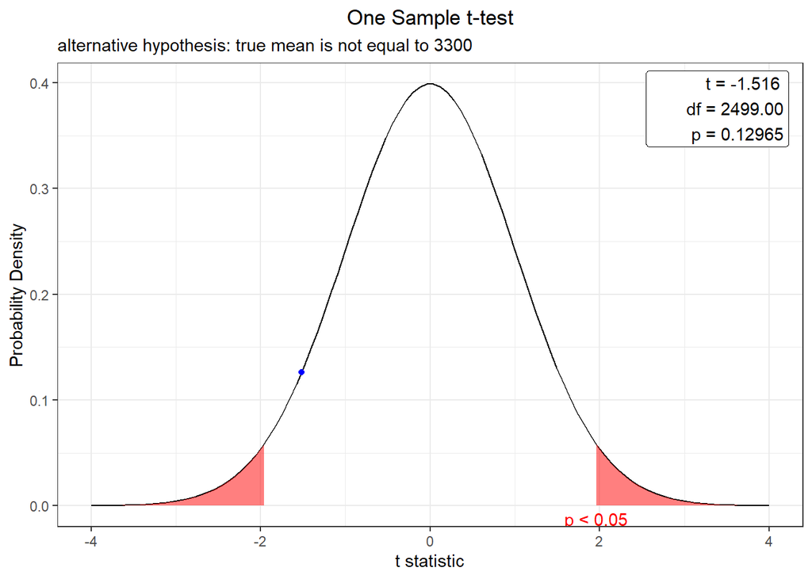

```r
library(webr)
plot(t_test_peso)
```

**Wilcox Test**

```r
wilcoxTestPeso <- wilcox.test(df$Peso,
                              mu = 3300,
                              conf.level = 0.95,
                              alternative = "two.sided",
                              p.adjust.methods = "bonferroni")
wilcoxTestPeso
```

```
##
##  Wilcoxon signed rank test with continuity correction
##
## data:  df$Peso
## V = 1495594, p-value = 0.9612
## alternative hypothesis: true location is not equal to 3300
```

Per entrambi i test il livello di significatività (Alfa) che delimita le zone di rifiuto è fissato al 5% (nella funzione indicato con `conf.level = 0.95` ovvero 1-Alfa)

Entrambi i test restituiscono un **p-value > Alfa** pertanto **Non rifiutiamo l’ipotesi nulla.**

## 4.2 Media lunghezza campione e media lunghezza popolazione

Possiamo ripetere la procedura fatta prima per la variabile peso, così da ottenere il seguente sistema di ipotesi:

- **H0:** Media lunghezza campione = Media lunghezza popolazione
- **H1:** Media lunghezza campione != Media lunghezza popolazione

**Calcolo della media lunghezza del campione:**

```r
mean(df$Lunghezza)
```

```
## [1] 494.692
```

*Media lunghezza campione = 494.692 mm*

**Media lunghezza popolazione:**

Come per la variabile peso mi avvarrò del dato registrato dall’[Ospedale Pediatrico Bambino Gesù](https://www.ospedalebambinogesu.it/da-0-a-30-giorni-come-si-presenta-e-come-cresce-80012/)

*Media lunghezza popolazione = 500.00 mm*

Pertanto il nostro sistema di ipotesi sarà:

- **H0:** Media lunghezza campione (494.692 mm) = Media lunghezza popolazione (500.00 mm)
- **H1:** Media lunghezza campione (494.692 mm) != Media lunghezza popolazione (500.00 mm)

*Saggiamo la normale distribuzione dei dati per la variabile* **Lunghezza** utilizzando la funzione `shapiro.test()`.

```r
shapiro.test(df$Lunghezza)
```

```
##
##  Shapiro-Wilk normality test
##
## data:  df$Lunghezza
## W = 0.90941, p-value < 2.2e-16
```

Anche qui il **p-value < di alfa**, i dati non si distribuiscono normalmente ed utilizzerò sia il *test parametrico* **t Student** (`t.test()`) che il *test non parametrico* **Wilcox test** (`wilcox.test()`) per saggiare l’ipotesi e confrontare i risultati.

**T di Student**

```r
t_test_lunghezza<-t.test(df$Lunghezza,
       mu = 500,
       conf.level = 0.95,
       alternative = "two.sided")
t_test_lunghezza
```

```
##
##  One Sample t-test
##
## data:  df$Lunghezza
## t = -10.084, df = 2499, p-value < 2.2e-16
## alternative hypothesis: true mean is not equal to 500
## 95 percent confidence interval:
##  493.6598 495.7242
## sample estimates:
## mean of x
##   494.692
```

Di seguito l’esito del t test, rappresentato graficamente:

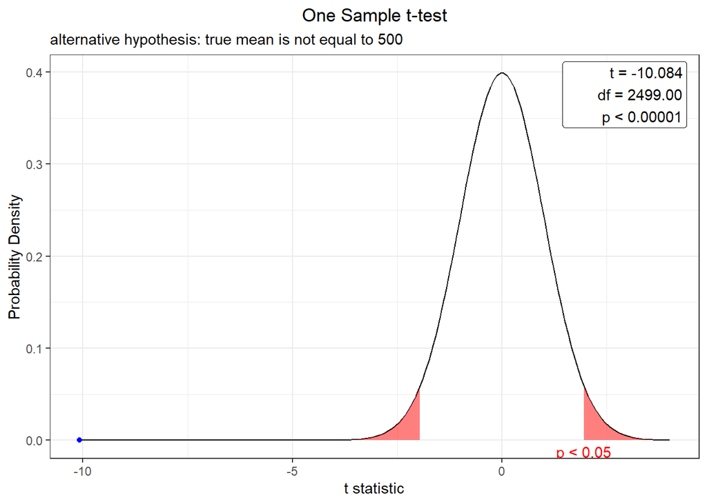

```r
library(webr)
plot(t_test_lunghezza)
```

**Wilcox Test**

```r
wilcoxTestLunghezza <- wilcox.test(df$Lunghezza,
                              mu = 500,
                              conf.level = 0.95,
                              alternative = "two.sided",
                              p.adjust.methods = "bonferroni")
wilcoxTestLunghezza
```

```
##
##  Wilcoxon signed rank test with continuity correction
##
## data:  df$Lunghezza
## V = 877236, p-value < 2.2e-16
## alternative hypothesis: true location is not equal to 500
```

Per entrambi i test il livello di significatività (Alfa) che delimita le zone di rifiuto è fissato al 5% (nella funzione indicato con `conf.level = 0.95` ovvero 1-Alfa)

Entrambi i test restituiscono un **p-value < Alfa** pertanto **l’ipotesi nulla è rifiutata a favore dell’ipotesi alternativa.**

# 5 Saggiare l’ipotesi di differenze significative, per le variabili, tra i due sessi

Ora verifico se ci sono differenze significativamente rilevanti, delle variabili, tra i due sessi.

Per saggiare le ipotesi potrei utilizzare il *t-test per campioni indipendenti* oppure la versione non paramentrica *Wilcox Test.*

Ricordo che le condizioni per poter utilizzare il t-test per campioni indipendenti sono:

- I due gruppi devono essere normalmente distribuiti, lo verifico con il **test di Shapiro-Wilk** `shapiro.test()`
- Le varianze dei due gruppi sono uguali, lo verifico con **f-test** `(var.test())`